# AustinsDataAnalysis

## R Markdown

Anaylze Austin’s Salamander Data, first we will see if any trait of interest can be explained by area or elevetion using pgls.

```r
#First load required packages and data: ape, phytools, geiger, nlme, ggplot2
raw_data<-read.csv("~/Documents/Caudata_PhyloComp_Data.csv")
cd<-raw_data[,-1]
rownames(cd)<-raw_data[,1]
cd <- na.omit(cd) ##remove all rows with any NA
ct<-read.nexus("~/Documents/caud.ultra.nexus")

#name.check(ct, cd)
pruning<-treedata(ct, cd)
pct<-pruning$phy
#name.check(pct, cd)
```

Let’s look at our tree!!!

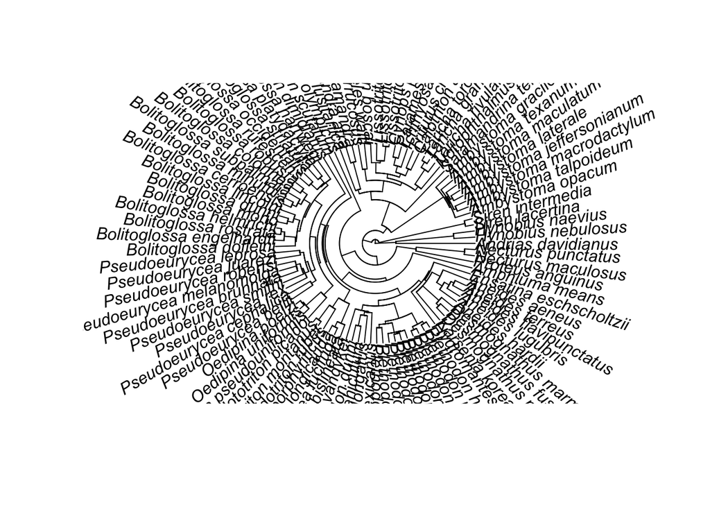

OOhhh looks bad

Moving on.. Now we will load trait values into their own varaibles and ask whether snout or total body lenght can be explained by elevation or area, and if so, which predictor is better.

```r
BodySize <- cd$TOTL_mm.totallength.quant
elev <- cd$elevation_m.maxaltitude.quant
area <- cd$area
snout <- as.numeric(cd$SnoutVentLength.Mean)


# to facilitate model comparison in pgls force ML instead of REML
#elevation, area, snout, TOTl
bodyVelev <- gls(BodySize~elev, correlation=corBrownian(phy=pct), data=cd, method="ML")
summary(bodyVelev)
```

```
## Generalized least squares fit by maximum likelihood
##   Model: BodySize ~ elev
##   Data: cd
##        AIC      BIC    logLik
##   1214.272 1222.118 -604.1361
##
## Correlation Structure: corBrownian
##  Formula: ~1
##  Parameter estimate(s):
## numeric(0)
##
## Coefficients:
##                Value Std.Error  t-value p-value
## (Intercept) 388.2076  73.99905 5.246115  0.0000
## elev          0.0050   0.01072 0.467496  0.6412
##
##  Correlation:
##      (Intr)
## elev -0.206
##
## Standardized residuals:
##       Min        Q1       Med        Q3       Max
## -1.972907 -1.617870 -1.445749 -1.185803  3.310319
##
## Residual standard error: 178.6206
## Degrees of freedom: 101 total; 99 residual
```

```r
snoutVelev<- gls(snout~elev, correlation=corBrownian(phy=pct), data=cd, method="ML")
summary(snoutVelev)
```

```
## Generalized least squares fit by maximum likelihood
##   Model: snout ~ elev
##   Data: cd
##        AIC      BIC    logLik
##   1160.787 1168.632 -577.3935
##
## Correlation Structure: corBrownian
##  Formula: ~1
##  Parameter estimate(s):
## numeric(0)
##
## Coefficients:
##                Value Std.Error    t-value p-value
## (Intercept) 119.6008  56.78510  2.1062001  0.0377
## elev         -0.0045   0.00823 -0.5465326  0.5859
##
##  Correlation:
##      (Intr)
## elev -0.206
##
## Standardized residuals:
##        Min         Q1        Med         Q3        Max
## -0.8058189 -0.1448565  0.2961151  0.6412097  1.0477608
##
## Residual standard error: 137.0691
## Degrees of freedom: 101 total; 99 residual
```

```r
bodyVarea <- gls(BodySize~area, correlation=corBrownian(phy=pct), data=cd, method="ML")
summary(bodyVelev)
```

```
## Generalized least squares fit by maximum likelihood
##   Model: BodySize ~ elev
##   Data: cd
##        AIC      BIC    logLik
##   1214.272 1222.118 -604.1361
##
## Correlation Structure: corBrownian
##  Formula: ~1
##  Parameter estimate(s):
## numeric(0)
##
## Coefficients:
##                Value Std.Error  t-value p-value
## (Intercept) 388.2076  73.99905 5.246115  0.0000
## elev          0.0050   0.01072 0.467496  0.6412
##
##  Correlation:
##      (Intr)
## elev -0.206
##
## Standardized residuals:
##       Min        Q1       Med        Q3       Max
## -1.972907 -1.617870 -1.445749 -1.185803  3.310319
##
## Residual standard error: 178.6206
## Degrees of freedom: 101 total; 99 residual
```

```r
snoutVarea<- gls(snout~area, correlation=corBrownian(phy=pct), data=cd, method="ML")
summary(snoutVelev)
```

```
## Generalized least squares fit by maximum likelihood
##   Model: snout ~ elev
##   Data: cd
##        AIC      BIC    logLik
##   1160.787 1168.632 -577.3935
##
## Correlation Structure: corBrownian
##  Formula: ~1
##  Parameter estimate(s):
## numeric(0)
##
## Coefficients:
##                Value Std.Error    t-value p-value
## (Intercept) 119.6008  56.78510  2.1062001  0.0377
## elev         -0.0045   0.00823 -0.5465326  0.5859
##
##  Correlation:
##      (Intr)
## elev -0.206
##
## Standardized residuals:
##        Min         Q1        Med         Q3        Max
## -0.8058189 -0.1448565  0.2961151  0.6412097  1.0477608
##
## Residual standard error: 137.0691
## Degrees of freedom: 101 total; 99 residual
```

```r
AIC(bodyVelev)
```

```
## [1] 1214.272
```

```r
AIC(bodyVarea)
```

```
## [1] 1214.206
```

```r
AIC(snoutVelev)
```

```
## [1] 1160.787
```

```r
AIC(snoutVarea)
```

```
## [1] 1160.26
```

Here we can see that both predictor variables do a poor job of explaining either snout length or total body length, and the AIC values are within 1, so neither are better explanations than the other.

Now, lets move on to use PIC and see if the rate of evolution for snout and body size are correlated

```r
body_pic <- pic(BodySize, pct)
snout_pic <- pic(snout, pct)
picModel <- lm(body_pic ~ snout_pic + 0)
```

Check Assumptions for linear model

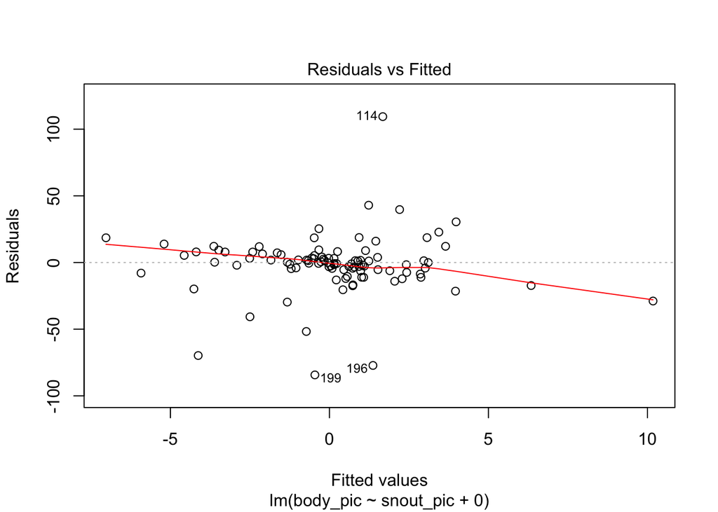

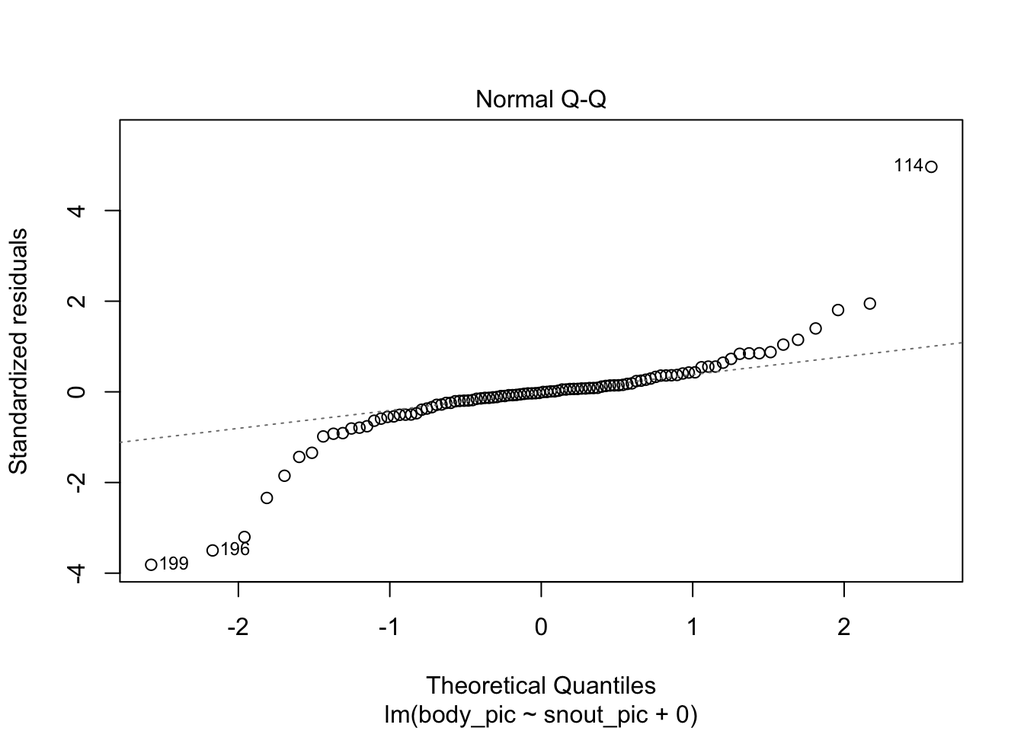

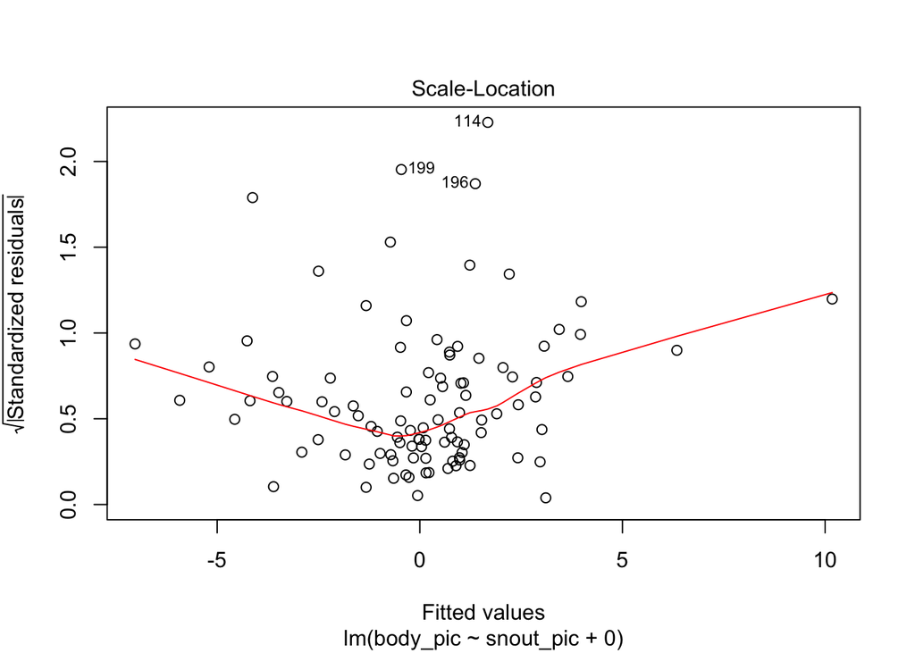

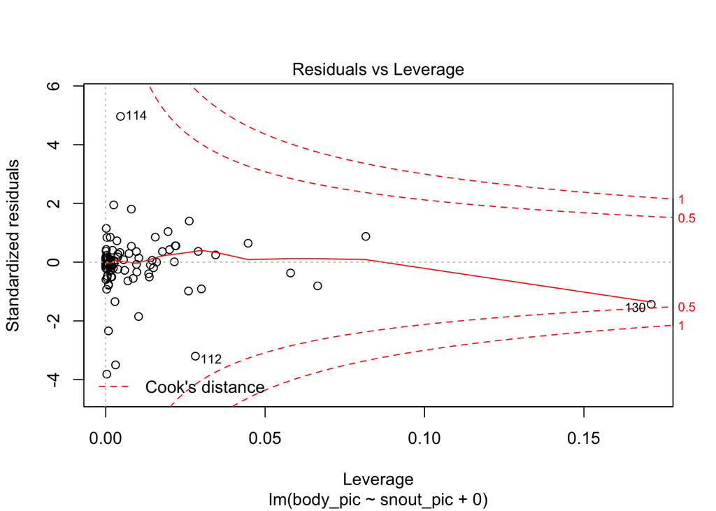

We see that the data are not particularly normal, and do not fit all of the assumptions for a linear regression. Maybe we could transform the data? Maybe, but we’ll worry about that another day.

```r
summary(picModel)
```

```
##
## Call:
## lm(formula = body_pic ~ snout_pic + 0)
##
## Residuals:
##     Min      1Q  Median      3Q     Max
## -84.279  -6.203  -0.288   5.493 109.434
##
## Coefficients:
##           Estimate Std. Error t value Pr(>|t|)
## snout_pic  -0.2283     0.2051  -1.113    0.268
##
## Residual standard error: 22.1 on 99 degrees of freedom
## Multiple R-squared:  0.01236,    Adjusted R-squared:  0.002387
## F-statistic: 1.239 on 1 and 99 DF,  p-value: 0.2683
```

Here we see that there is not strong evidence that the variation in snout can exlain the variation in total body length.

## Fitting Models of trait evolution

Now we will use the fit continuous functuon from geiger to fit models of brownian motion and OU.

```r
names(BodySize) <- pct$tip.label
bodyBM <- fitContinuous(pct, dat=BodySize, model="BM")
bodyBM
```

```
## GEIGER-fitted comparative model of continuous data
##  fitted 'BM' model parameters:
##  sigsq = 484.602016
##  z0 = 184.127871
##
##  model summary:
##  log-likelihood = -662.091682
##  AIC = 1328.183365
##  AICc = 1328.305814
##  free parameters = 2
##
## Convergence diagnostics:
##  optimization iterations = 100
##  failed iterations = 0
##  frequency of best fit = 1.00
##
##  object summary:
##  'lik' -- likelihood function
##  'bnd' -- bounds for likelihood search
##  'res' -- optimization iteration summary
##  'opt' -- maximum likelihood parameter estimates
```

```r
bodyOU <- fitContinuous(pct, dat=BodySize, model="OU")
bodyOU
```

```
## GEIGER-fitted comparative model of continuous data
##  fitted 'OU' model parameters:
##  alpha = 0.030944
##  sigsq = 1408.678531
##  z0 = 174.380495
##
##  model summary:
##  log-likelihood = -646.987521
##  AIC = 1299.975042
##  AICc = 1300.222465
##  free parameters = 3
##
## Convergence diagnostics:
##  optimization iterations = 100
##  failed iterations = 74
##  frequency of best fit = NA
##
##  object summary:
##  'lik' -- likelihood function
##  'bnd' -- bounds for likelihood search
##  'res' -- optimization iteration summary
##  'opt' -- maximum likelihood parameter estimates
```

We see that the OU model is a better fit to the body size data than a BM model….maybe this is why the pgls (which was using correlated BM) revealed not so much information…

Let’s look at snout length now….

```r
names(snout) <- pct$tip.label
snoutBM <- fitContinuous(pct, dat=snout, model="BM")
snoutBM
```

```
## GEIGER-fitted comparative model of continuous data
##  fitted 'BM' model parameters:
##  sigsq = 114.948838
##  z0 = 163.518751
##
##  model summary:
##  log-likelihood = -589.430221
##  AIC = 1182.860441
##  AICc = 1182.982890
##  free parameters = 2
##
## Convergence diagnostics:
##  optimization iterations = 100
##  failed iterations = 0
##  frequency of best fit = 1.00
##
##  object summary:
##  'lik' -- likelihood function
##  'bnd' -- bounds for likelihood search
##  'res' -- optimization iteration summary
##  'opt' -- maximum likelihood parameter estimates
```

```r
snoutOU <- fitContinuous(pct, dat=snout, model="OU")
snoutOU
```

```
## GEIGER-fitted comparative model of continuous data
##  fitted 'OU' model parameters:
##  alpha = 2.691619
##  sigsq = 24057.787658
##  z0 = 140.950495
##
##  model summary:
##  log-likelihood = -567.761445
##  AIC = 1141.522891
##  AICc = 1141.770313
##  free parameters = 3
##
## Convergence diagnostics:
##  optimization iterations = 100
##  failed iterations = 71
##  frequency of best fit = NA
##
##  object summary:
##  'lik' -- likelihood function
##  'bnd' -- bounds for likelihood search
##  'res' -- optimization iteration summary
##  'opt' -- maximum likelihood parameter estimates
```

Again…we are seeing that the OU model is a better fit to the snout data than the BM model.

Then agian, we did have to remove 3/4 of the data because of NAs at the beginning of this analysis. Removing all of that data could mean that these results are bias/flat out wrong. Who’s to say.